# Homework 2

Nicholas Esposito

10/13/2022

### Load the data

Y - Deflection of galvonometer, X - Area of the wires on the coupling

```r
exp_data <- read.table("https://users.stat.ufl.edu/~winner/data/explosives1.dat",
                       header = F, col.names = c("coupling", "areaWire", "defGalv"))
```

### a) The fitted equation and residuals

The fitted equation for the simple linear model relating the deflection of galvonometer (Y) to the area of the wires on the coupling (X) is:

Y = 184.436 - 0.695X

```r
X <- exp_data$areaWire
Y <- exp_data$defGalv
lm_exp_data <- lm(Y ~ X)
n <- length(Y)

summary(lm_exp_data)
```

```
##
## Call:
## lm(formula = Y ~ X)
##
## Residuals:
##     Min      1Q  Median      3Q     Max
## -10.042  -6.459  -0.068   2.901  19.386
##
## Coefficients:
##              Estimate Std. Error t value Pr(>|t|)
## (Intercept) 184.43569    2.91526   63.27  < 2e-16 ***
## X            -0.69537    0.03383  -20.56 6.39e-15 ***
## ---
## Signif. codes:  0 '***' 0.001 '**' 0.01 '*' 0.05 '.' 0.1 ' ' 1
##
## Residual standard error: 7.337 on 20 degrees of freedom
## Multiple R-squared:  0.9548, Adjusted R-squared:  0.9526
## F-statistic: 422.6 on 1 and 20 DF,  p-value: 6.386e-15
```

```r
# OR: Calculation by hand
xbar <- mean(X)
ybar <- mean(Y)
SSxy <- sum((X-xbar)*(Y-ybar))
SSxx <- sum((X-xbar)^2)
b1 <- SSxy/SSxx
b0 <- ybar - b1*xbar
yhat <- b0 + b1*X

eq.out <- cbind(b1, b0)
colnames(eq.out) <- c("b1", "b0")
rownames(eq.out) <- c("Fitted equation")
round(eq.out, 4)
```

```
##                      b1       b0
## Fitted equation -0.6954 184.4357
```

The residuals are:

```
##            1            2            3            4            5            6
##   6.25989890   2.75989890   4.75989890   4.48502508  -7.01497492   0.98502508
##            7            8            9           10           11           12
##  -6.59448305  -0.09448305  -7.54155105 -10.04155105  -0.04155105   1.41869488
##           13           14           15           16           17           18
##   1.41869488  -0.58130512  -7.59788767  -1.59788767  -9.09788767  -6.05154464
##           19           20           21           22
##   2.94845536  -1.05154464  12.88552978  19.38552978
```

### b) Plot of Y vs X

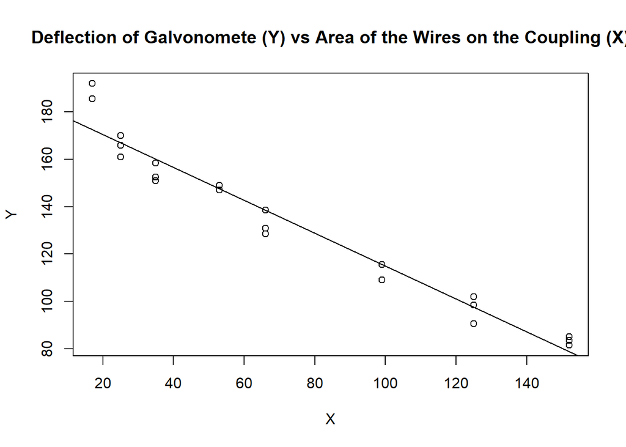

```r
plot(Y ~ X, main = "Deflection of Galvonomete (Y) vs Area of the Wires on the Coupling (X)")
abline(lm_exp_data)
```

### c) Residual Plot of e vs X

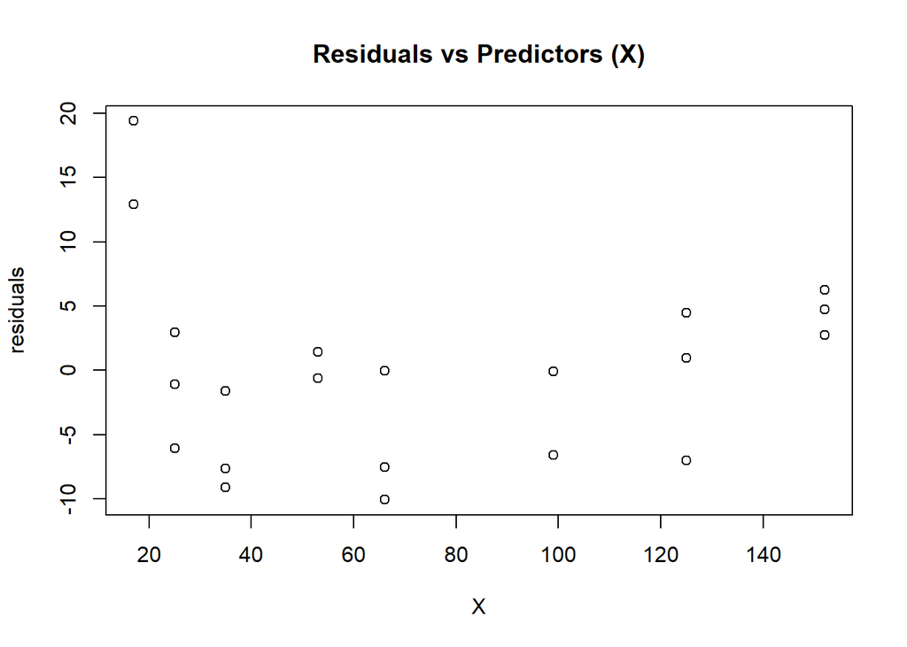

```r
plot(X, residuals, main = "Residuals vs Predictors (X)")
abline(lm_exp_data)
```

### d) A test of whether deflections (Y) are associated with area of the wires (X)

Use Pearson’s correlation test to test H0: p = 0 versus Ha: p != 0 (alpha=0.05).

Test-Statistic (t*): -20.557 Critical Value, or t(0.975, 20): 2.086 Rejection Region: |t*| >= t(0.975, 20)

Since |-20.557| >= 2.086, the test statistic t* is statistically significant at alpha = 0.05. Thus, we reject the null hypothesis H0: p = 0 and conclude that there is a linear association between deflections (Y) and area of the wires (X).

```r
# Calculation by hand
SSyy <- sum((Y-ybar)^2)
R <- SSxy / sqrt(SSxx*SSyy)
t.Cor <- R*sqrt(n-2) / sqrt(1-R^2)

cor.out <- cbind(R,t.Cor)
colnames(cor.out) <- c("R", "t*")
rownames(cor.out) <- c("Correlation Test")
round(cor.out, 4)
```

```
##                        R       t*
## Correlation Test -0.9771 -20.5573
```

### e) Normal Probability Plot of the residuals

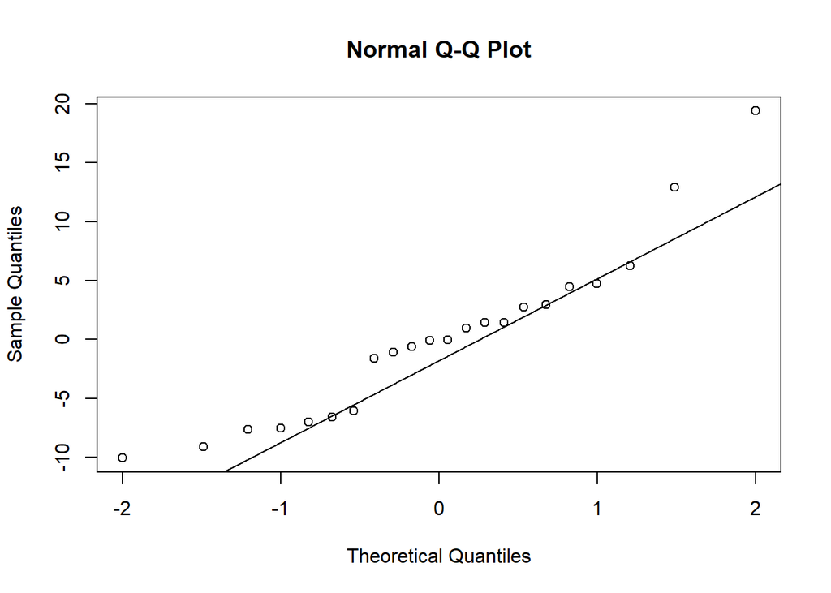

```r
qqnorm(residuals)
qqline(residuals)
```

### f) Shapiro-Wilk test for normality

H0: The errors follow a normal distribution.

Ha: The errors do not follow a normal distribution.

The Shapiro-Wilk test produces a p-value of 0.09. Since 0.09 > 0.05, we fail to reject H0, and thus conclude that the residuals follow a normal distribution at the significance level 0.05.

```r
shapiro.test(residuals)
```

```
##
##  Shapiro-Wilk normality test
##
## data:  residuals
## W = 0.92354, p-value = 0.09004
```

### g) Brown-Forsyth test for constant variance

H0: There is equal variance among the errors.

Ha: There is unequal variance among the errors (Increasing or Decreasing in X).

We have test statistic t* = -0.5534, and will compare it against t(0.975, 20) = 2.086.

Since |t*| = 0.5534 < 2.086, we fail to reject H0, and thus conclude that there is equal variance among the errors at the significance level 0.05.

```r
group.BF <- ifelse(exp_data$coupling <= 4, 1, 2) # Breaks the data by coupling value

fit1 <- lm(exp_data$defGalv ~ exp_data$areaWire)
res1 <- resid(fit1)

median_e1 <- median(residuals[group.BF == 1]) # Median residuals
median_e2 <- median(residuals[group.BF == 2])

median_e <- rep(c(median_e1, median_e2), each = 11)

d.BF <- abs(res1 - median_e)
cbind(group.BF, d.BF)
```

```
##    group.BF        d.BF
## 1         1  6.30144996
## 2         1  2.80144996
## 3         1  4.80144996
## 4         1  4.52657613
## 5         1  6.97342387
## 6         1  1.02657613
## 7         1  6.55293199
## 8         1  0.05293199
## 9         1  7.50000000
## 10        1 10.00000000
## 11        1  0.00000000
## 12        2  2.00000000
## 13        2  2.00000000
## 14        2  0.00000000
## 15        2  7.01658255
## 16        2  1.01658255
## 17        2  8.51658255
## 18        2  5.47023952
## 19        2  3.52976048
## 20        2  0.47023952
## 21        2 13.46683490
## 22        2 19.96683490
```

```r
# Brute force calculation
dbar1 <- mean(d.BF[group.BF == 1])
dbar2 <- mean(d.BF[group.BF == 2])

var1 <- var(d.BF[group.BF == 1])
var2 <- var(d.BF[group.BF == 2])

n1 <- length(d.BF[group.BF == 1])
n2 <- length(d.BF[group.BF == 2])

var.p <- ((n1-1)*var1 + (n2-1)*var2) / (n1+n2-2) # Pooled variance

t.BF <- (dbar1 - dbar2) / sqrt(var.p*(1/n1 + 1/n2)) # T-statistic

p.t.BF <- 2*(1-pt(abs(t.BF), n1+n2-2)) # P-value

BF.out <- cbind(dbar1 - dbar2, t.BF, p.t.BF)
colnames(BF.out) <- c("Mean Diff", "t*", "2P(>|t*|))")
rownames(BF.out) <- c("BF Test")
round(BF.out, 4)
```

```
##         Mean Diff      t* 2P(>|t*|))
## BF Test   -1.1743 -0.5534     0.5861
```

### h) Breusch-Pagan Test for constant variance

H0: There is equal variance among the errors.

Ha: There is unequal variance among the errors.

We have test statistic X^2* = 2.5916, and will compare it against X^2(0.95, 1) = 3.8415.

Since X^2* = 2.5916 < 3.8415, we fail to reject H0, and thus conclude that there is equal variance among the errors at the significance level 0.05.

```r
# 1. Find ei^2
residuals.sq <- residuals^2

# 2. Fit Regression of ei^2 on X
lm.BP <- lm(residuals.sq ~ X)
summary(lm.BP)
```

```
##
## Call:
## lm(formula = residuals.sq ~ X)
##
## Residuals:
##    Min     1Q Median     3Q    Max
## -76.88 -57.45  -5.59  19.19 292.95
##
## Coefficients:
##             Estimate Std. Error t value Pr(>|t|)
## (Intercept)  93.1956    32.0989   2.903  0.00879 **
## X            -0.6085     0.3724  -1.634  0.11792
## ---
## Signif. codes:  0 '***' 0.001 '**' 0.01 '*' 0.05 '.' 0.1 ' ' 1
##
## Residual standard error: 80.79 on 20 degrees of freedom
## Multiple R-squared:  0.1178, Adjusted R-squared:  0.07365
## F-statistic:  2.67 on 1 and 20 DF,  p-value: 0.1179
```

```r
newR.sq <- 0.1178 # From summary of new linear model
chi.sq <- newR.sq * n # 22 observations

crit.X <- qchisq(0.95, 1, lower.tail=TRUE)

# Output
BP.out <- cbind(chi.sq, crit.X)
colnames(BP.out) <- c("Chi-Sq*", "Crit. Value")
rownames(BP.out) <- c("BP Test")
round(BP.out, 4)
```

```
##         Chi-Sq* Crit. Value
## BP Test  2.5916      3.8415
```

### i) F-test for lack-of-fit

H0: E(Yi) = B0 + B1Xi - there is no lack of fit in the model.

Ha: E(Yi) != B0 + B1Xi - there is lack of fit in the model.

We have the test statistic F* = 7.8407. Our p-value is 0.0007684.

Since 0.0007684 < 0.05, we reject H0, and thus conclude that there is lack of fit in the model at the significance level 0.05.

```r
# Full vs. reduced
lm_exp_data_full <- lm(Y ~ factor(X))
lm_exp_data_reduced <- lm(Y ~ X)
anova(lm_exp_data_reduced, lm_exp_data_full)
```

```
## Analysis of Variance Table
##
## Model 1: Y ~ X
## Model 2: Y ~ factor(X)
##   Res.Df     RSS Df Sum of Sq      F    Pr(>F)
## 1     20 1076.63
## 2     14  246.92  6    829.72 7.8407 0.0007684 ***
## ---
## Signif. codes:  0 '***' 0.001 '**' 0.01 '*' 0.05 '.' 0.1 ' ' 1
```

### j) Obtain “best” power transformation method, based on Box-Cox transformations

First, we run series of power transformations and find the “best” lambda value, which is -0.2222. This lambda can be used to fit a new linear regression model, which relates (Y^lambda-1) / lambda to X, where lambda is -0.2222.

In R, the model is fitted by lm((Y^lambda-1) / lambda ~ X).

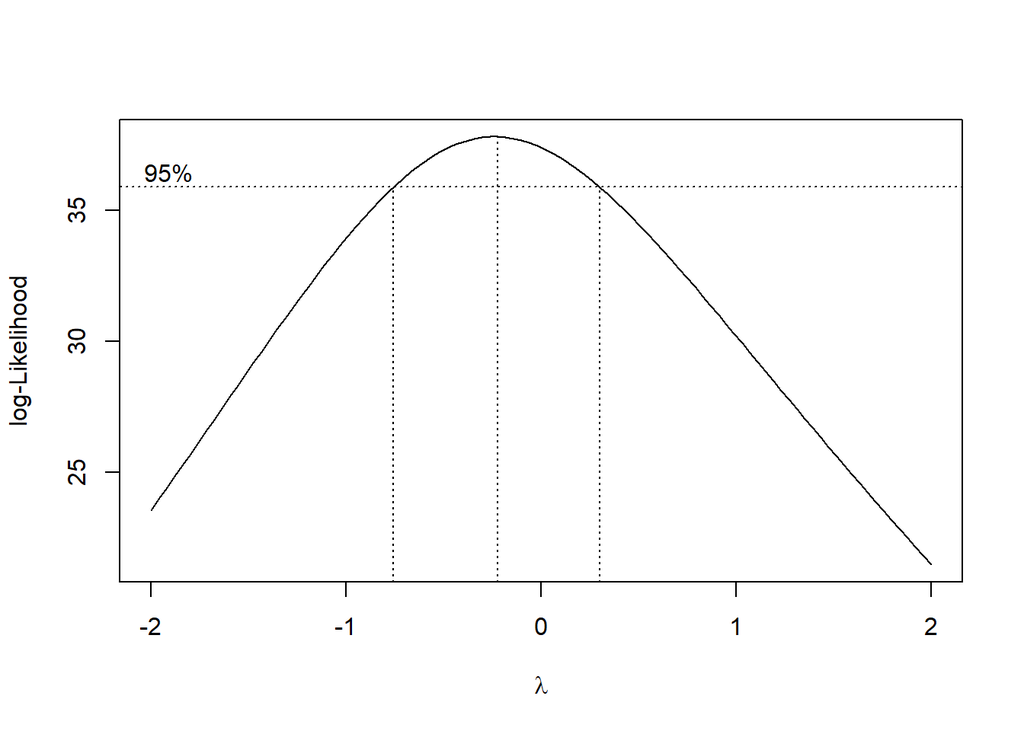

```r
# Runs series of power transformations and plots
lm_exp_data_BC <- boxcox(lm_exp_data, plot=T)
```

```r
# Print out "best" lambda (max lambda value)
lambda <- lm_exp_data_BC$x[which.max(lm_exp_data_BC$y)]

BC.out <- cbind(lambda)
colnames(BC.out) <- c("Best Lambda")
rownames(BC.out) <- c("Box-Cox")
round(BC.out, 4)
```

```
##         Best Lambda
## Box-Cox     -0.2222
```

The 95% confidence interval for β0 is (178.3546, 190.5168). We are 95% confident the true value for β0 (the intercept of the regression line) falls between 178.3546 and 190.5168.

The 95% confidence interval for β1 is (-0.7659, -0.6248). We are 95% confident the true value for β1 (the mean change) falls between -0.7659 and -0.6248.

```r
# Calculation by hand
SSE <- sum((Y-yhat)^2)
MSE <- SSE / (n - 2) # n = 22
s.b1 <- sqrt(MSE) / sqrt(SSxx)
s.b0 <- sqrt(MSE*(1/n + (xbar)^2 / SSxx))

t.value <- qt(0.975, n-2)

# b0 CI
b0.LL <- b0 - t.value*s.b0
b0.UL <- b0 + t.value*s.b0

CI.b0.out <- cbind(b0.LL, b0.UL)
colnames(CI.b0.out) <- c("Lower Bound", "Upper Bound")
rownames(CI.b0.out) <- c("95% CI for b0")
round(CI.b0.out, 4)
```

```
##               Lower Bound Upper Bound
## 95% CI for b0    178.3546    190.5168
```

```r
# b1 CI
b1.LL <- b1 - t.value*s.b1
b1.UL <- b1 + t.value*s.b1

CI.b1.out <- cbind(b1.LL, b1.UL)
colnames(CI.b1.out) <- c("Lower Bound", "Upper Bound")
rownames(CI.b1.out) <- c("95% CI for b1")
round(CI.b1.out, 4)
```

```
##               Lower Bound Upper Bound
## 95% CI for b1     -0.7659     -0.6248
```

### l) Obtain an approximate 95% Prediction Interval for the Area of the coupling,

when a deflection of 115 was observed (See section 4.6)

The 95% prediction interval for Xhat is (77.1829, 122.5269). We are 95% confident the true value for Xhat falls between 77.1829 and 122.5269 when Yh = 115.

```r
y.h <- 115
xhat.h <- (y.h - b0) / b1 # Point estimate
s.pred <- sqrt((MSE / b1^2) * (1 + 1/n + ((xhat.h - xbar)^2 / SSxx)))
t.value <- qt(0.975, n-2)

# 95% CI for Xhat.h, given Yh = 115
PI.Xhat.LL <- xhat.h - (t.value*s.pred)
PI.Xhat.UL <- xhat.h + (t.value*s.pred)

PI.Xhat.out <- cbind(PI.Xhat.LL, PI.Xhat.UL)
colnames(PI.Xhat.out) <- c("Lower Bound", "Upper Bound")
rownames(PI.Xhat.out) <- c("95% PI for Xhat.h, given Yh = 115")
round(PI.Xhat.out, 4)
```

```
##                                   Lower Bound Upper Bound
## 95% PI for Xhat.h, given Yh = 115     77.1829    122.5269
```

### m) Obtain X’X, X’Y, (X’X)-1, beta-hat, MSE, and s2{beta-hat}

```
##
##  X'X:
```

```
##      [,1]   [,2]
## [1,]   22   1600
## [2,] 1600 163412
```

```
##
##  X'Y:
```

```
##        [,1]
## [1,]   2945
## [2,] 181466
```

```
##
##  (X'X)^-1:
```

```
##              [,1]          [,2]
## [1,]  0.157876228 -1.545798e-03
## [2,] -0.001545798  2.125472e-05
```

```
##
##  beta-hat:
```

```
##             [,1]
## [1,] 184.4356871
## [2,]  -0.6953657
```

```
##
##  MSE:
```

```
##          [,1]
## [1,] 53.83166
```

```
##
##  s^2{beta-hat}:
```

```
##             [,1]         [,2]
## [1,]  8.49873934 -0.083212879
## [2,] -0.08321288  0.001144177
```